# Analise da atividade dos parlamentares no Twitter no ano de 2019

Igor Matheus Castor Diniz Pinheiro

```r
atividade = read_projectdata()
glimpse(atividade)
```

```
## Observations: 608
## Variables: 19
## $ id_parlamentar        <chr> "204554", "204521", "204379", "204560", "2…
## $ casa                  <chr> "câmara", "câmara", "câmara", "câmara", "c…
## $ nome_eleitoral        <chr> "ABÍLIO SANTANA", "ABOU ANNI", "ACÁCIO FAV…
## $ partido               <chr> "PR", "PSL", "PROS", "PSDB", "NOVO", "PP",…
## $ UF                    <chr> "BA", "SP", "AP", "BA", "SP", "GO", "MG", …
## $ twitter               <chr> "AbilioSantana_", "abouannipv", "FavachoAc…
## $ seguidores            <dbl> NA, NA, NA, NA, 4652, NA, NA, NA, NA, NA, …
## $ segue                 <dbl> NA, NA, NA, NA, 315, NA, NA, NA, NA, NA, N…
## $ n_proprio             <dbl> 0, 0, 0, 0, 99, 0, 0, 0, 0, 0, 0, 0, NA, 4…
## $ n_retweet             <dbl> 0, 0, 0, 0, 9, 0, 0, 0, 0, 0, 0, 0, NA, 1,…
## $ engaj_total           <dbl> 0, 0, 0, 0, 7090, 0, 0, 0, 0, 0, 0, 0, NA,…
## $ engaj_total_proprio   <dbl> 0, 0, 0, 0, 6701, 0, 0, 0, 0, 0, 0, 0, NA,…
## $ engaj_total_retweet   <dbl> 0, 0, 0, 0, 389, 0, 0, 0, 0, 0, 0, 0, NA, …
## $ engaj_mediano         <dbl> 0.0, 0.0, 0.0, 0.0, 26.5, 0.0, 0.0, 0.0, 0…
## $ engaj_mediano_proprio <dbl> 0.0, 0.0, 0.0, 0.0, 22.5, 0.0, 0.0, 0.0, 0…
## $ engaj_mediano_retweet <dbl> 0.0, 0.0, 0.0, 0.0, 0.0, 0.0, 0.0, 0.0, 0.…
## $ engaj_max             <dbl> 0, 0, 0, 0, 1031, 0, 0, 0, 0, 0, 0, 0, NA,…
## $ engaj_max_proprio     <dbl> 0, 0, 0, 0, 1031, 0, 0, 0, 0, 0, 0, 0, NA,…
## $ engaj_max_retweet     <dbl> 0, 0, 0, 0, 99, 0, 0, 0, 0, 0, 0, 0, NA, 4…
```

## Levando em consideração os parlamentares e seus respectivos alcances em redes sociais, Quais são os partidos que possuem o maior poder de influência no twitter?

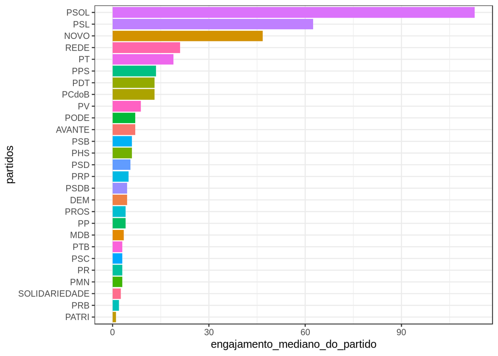

```r
engaj_mediano_partido =
  atividade %>%
  na.omit(engaj_mediano) %>%
  group_by(partido) %>%
  filter(partido != 'S/Partido') %>%
  summarise(engaj_med_part = median(engaj_mediano))

engaj_mediano_partido %>%
  group_by(partido)%>%
  ggplot(aes(x= reorder(partido, engaj_med_part), y= engaj_med_part,fill = partido) ) +
  geom_col(show.legend = FALSE)+
  labs(y='engajamento_mediano_do_partido', x= 'partidos')+
  coord_flip()
```

Considerando que o partido que possui maior poder de influência nas redes sociais é aquele que possui maior nível de engajamento, e evitando os pontos fora da curva, o que responde nossa pergunta é a mediana dos dos engajamentos_medianos de cada partido. Dessa forma poodemos perceber no gráfico que o PSOL e PSL estão bem a frente. O que difere do pensamento crítico do autor da questão, o qual imaginava PSOL, PT e PSDB. Importante ressaltar que o engajamento_mediano de cada partido é a mediana do engajamento de todos os seus parlamentares, que por sua vez são likes e retweets em seu conteúdo, ou seja aquele partido que possui maior engajamento mediano, é o partido que possui um número considerável de ações (likes/retweets emseu material).

```r
##como selecionar partido, nome e maisAtivos
sumarios = atividade %>%
    ##select(nome_eleitoral,partido,n_proprio,n_retweet)%>%
    group_by(nome_eleitoral)%>%
    na.omit(atividade)%>%
    summarise(partido, casa,maisAtivos = n_proprio+n_retweet)%>%
    arrange(desc(maisAtivos))


glimpse(sumarios)
```

```
## Observations: 370
## Variables: 4
## $ nome_eleitoral <chr> "BACELAR", "ALVARO DIAS", "HUMBERTO COSTA", "MÁRC…
## $ partido        <chr> "PODE", "PODE", "PT", "PCdoB", "PT", "PSL", "PSL"…
## $ casa           <chr> "câmara", "senado", "senado", "câmara", "câmara",…
## $ maisAtivos     <dbl> 2000, 1000, 1000, 1000, 1000, 999, 999, 999, 999,…
```

## Quais são os partidos que possuem os parlamentares mais ativos?

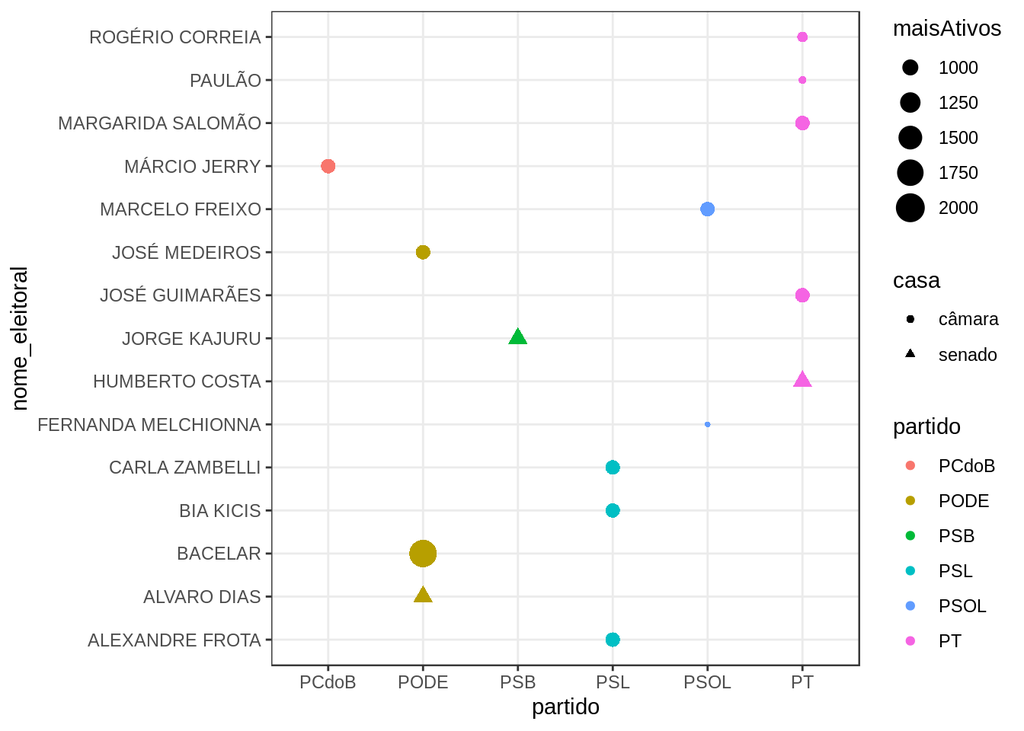

```r
sumarios %>%
  head(sumarios, n=15L)%>%
  ggplot(aes(x=nome_eleitoral,y=partido, size=maisAtivos,color =partido, shape=casa))+
  geom_point()+
  coord_flip()
```

Considerando que um parlamentar ativo é aquele que possui twwets ou que retweeta algum conteúdo, pegando os 15 que possuem o maior índice de atividade temos o resultado exibido no gráfico acima. O que também cofronta com o resultado esperado pelo pesquisador, que esperava que fosse algum parlamentar do PSL ou PT.

## Quantos parlamentares por partido temos? Quantos do senado e quantos da câmara? O número de parlamentares por partido reflete quais são os partidos com maior poder de influência, como vimos na primeira questão ?

### Parlamentares por partido

```r
Count = atividade %>%
  group_by(partido)%>%
  count() %>%
  arrange(n)

glimpse(Count)
```

```
## Observations: 30
## Variables: 2
## Groups: partido [30]
## $ partido <chr> "DC", "PPL", "S/Partido", "PHS", "PMN", "PRP", "PATRI", …
## $ n       <int> 1, 1, 1, 3, 3, 3, 4, 4, 4, 7, 8, 9, 9, 11, 11, 11, 11, 1…
```

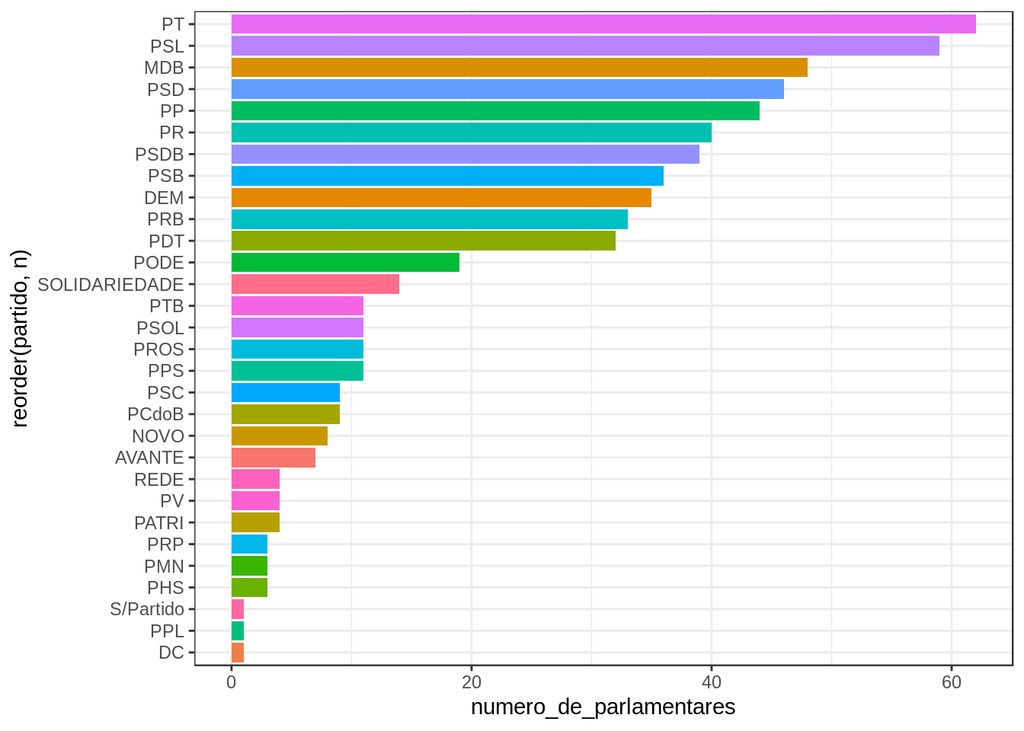

```r
Count %>%
  ggplot(aes(x = reorder(partido,n), y=n, fill=partido)) +
  geom_col(show.legend = FALSE)+
  coord_flip()+
  labs(y='numero_de_parlamentares')
```

### Parlamentares senado x Parlamentares Câmara.

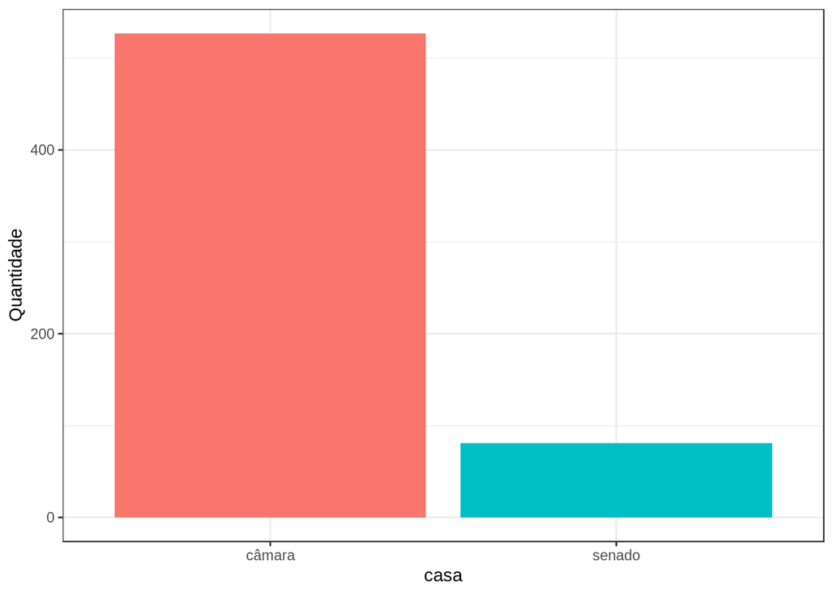

```r
atividade %>%
  ggplot(aes(x= casa, fill=casa))+
  geom_bar(show.legend = FALSE)+
  labs(x='casa', y='Quantidade')
```

É possível perceber que temos muito mais parlamentares da câmara do que parlamentares do Senado. MAS…

## SE considerarmos a atividade mediana, quem são os mais ativos, câmara ou senado?

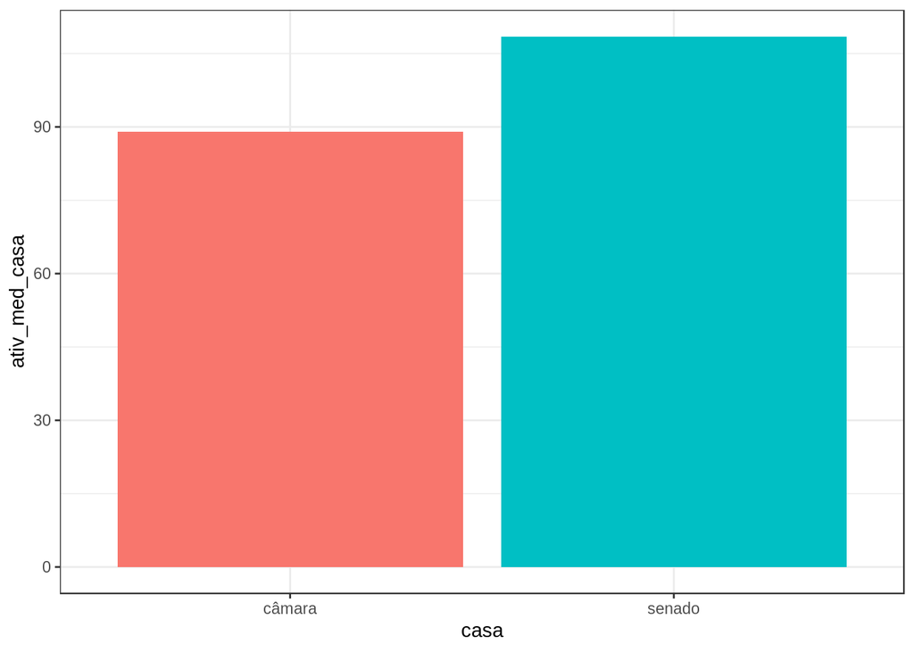

```r
atividade_mediana_casa =
  atividade %>%
  na.omit(engaj_mediano) %>%
  group_by(casa) %>%
  filter(partido != 'S/Partido') %>%
  summarise(ativ_med_casa = median(n_proprio+n_retweet))

atividade_mediana_casa %>%
  ggplot(aes(x= casa, y= ativ_med_casa, fill = casa) ) +
  geom_col(show.legend = FALSE)
```

Portanto, mesmo que o núemro de parlamentares na câmara seja maior, os senadores são os mais ativos na rede social!!

## O número de parlamentares tem impacto no poder de influência do partido?

De acordo com os gráficos obtidos na figura 1 e na figura 3, podemos confrotar o fato de que o PT tem o maior número de parlamentares com twitter, entretanto a quantidade não teve um impacto muito grande no nível de influência e poder de engajamento na rede social. O cenário inverso pode ser notado com o partido do PSOL que não possui muitos parlamentares no twitter entretanto está em primeiro lugar em nível de engajamento.